# Unit 2 Pre-Live

Johnny Vogt

2025-09-01

## Discussion 1: Main Ideas

1. Suppose that the true relationship between a response variable and one predictor variable is $y=\beta_0+\beta_1x+\beta_2x^2+\varepsilon$. For a given data set, if the analyst fits a fifth degree polynomial to the data, the validation MSE will be higher or lower than the validation MSE generated from a quadratic model. Answer the question again replacing the word “validation” with “train”.

Validation MSE: If the true shape of the response variable and the predictor variable is y=beta1x + beta2x + Epsilon, the fifth degree polynomial woud be *higher* than the MSE than the quadratic model. Train MSE: On the training set, the MSE would show the opposite results. It would be likely that the fith degree polynomial model would be overfitted to the training set and wouldn’t be able to stand up to scrutiny from testing against a validation set.

2. Under what scenario do you think performing feature selection would not be very helpful to do?

Feature Selection doesnt help much when your model is already simple. Such as a data set that only has one or two predictors and they NEED to be in model as well. Also, it wouldnt be helpful when you’re performing an EDA and need to start investigating the data set.

## Discussion 2: Forward Selection and Error Metrics

The following data set, `GolfData2.csv`, contains various measurements on professional golfers. There are three variables related to monetary compensation. Additionally, numerous attributes of the golfer are provided that can be lumped together in two categories. Variables such as average drive and driving accuracy tells us a little bit about the golfers ability to hit the ball long range. Additional variables such as greens, average putt, and saves tell us how good the golfer is with their “short game” when working on shots closer to the hole. Finally, there are some additional “mystery variables” with generic labeling.

```r
setwd("C:/Users/Owner/git/School/DS6372_Applied_Statistics/")
golf<-read.csv("/Users/Owner/git/School/DS6372_Applied_Statistics/Unit 2/Pre-Live/GolfData2.csv",header=T)
names(golf)
```

```
##  [1] "Name"         "Age"          "AvgDrive"     "DriveAcc"     "Greens"
##  [6] "AvgPutts"     "Save"         "Money.Rank"   "Events"       "TotalWinning"
## [11] "AvgWinnings"  "V12"          "V13"          "V14"          "V15"
## [16] "V16"          "V17"          "V18"          "V19"          "V20"
## [21] "V21"          "V22"          "V23"          "V24"          "V25"
## [26] "V26"          "V27"          "V28"          "V29"          "V30"
## [31] "V31"
```

A. Suppose we wanted to build a regression model to predict a players average winnings. Which variables in the data set do you think should be considered for use in a feature selection model and which ones should not? For the ones that should not, explain your reasons.

In Feature selection model <-> Age, AvgDrive, DriveAcc, Greens, AvgPutts, Save, Events -> These variables attribute towards “why” a player may earn more “winnings” These are different ways for a player to earn more money and/or why they are earning more money. I.e. participating in more vents, hitting further and/or accurately, and how young a person is.

Leaving out of Feature Selection Model <-> Name, Money.Rank, TotalWinning, V12-31 - > The three variables in which we *know*, do not attribute towards a players skill and could risk overfitting the model. V12-31, we do not know what these are and shouldnt use them. Although it may be interesting to see what the model looks like using them.

B. The following code chunk performs forward selection and computes traditional regression error metrics for each model iteration using log(AvgWinnings) as the response variable. When running the `regsubsets` function, it records Adjusted R-square, Residual Sums of Squares, and the BIC. The red point highlights the best metric across all of the models.

```r
library(leaps)
golf2<-golf[,-c(1,8,10)]
reg.fwd=regsubsets(log(AvgWinnings)~.,data=golf2,method="forward",nvmax=20)

summary(reg.fwd)$adjr2
```

```
##  [1] 0.3297415 0.5660627 0.6039178 0.6189419 0.6263985 0.6336879 0.6398874
##  [8] 0.6464599 0.6516239 0.6553905 0.6584060 0.6617997 0.6628219 0.6640956
## [15] 0.6643452 0.6637931 0.6629888 0.6617231 0.6605712 0.6593374
```

```r
summary(reg.fwd)$rss
```

```
##  [1] 126.87220  81.71594  74.20086  71.01450  69.26034  67.55157  66.05696
##  [8]  64.50638  63.22427  62.20445  61.32682  60.38757  59.87606  59.32213
## [15]  58.95055  58.71947  58.53112  58.42087  58.28863  58.16811
```

```r
summary(reg.fwd)$bic
```

```
##  [1]  -68.86949 -149.81790 -163.44855 -166.77321 -166.39736 -166.01555
##  [7] -165.12273 -164.50026 -163.15703 -161.06621 -158.57309 -156.32004
## [13] -152.70922 -149.25279 -145.20623 -140.69791 -136.04952 -131.14093
## [19] -126.30700 -121.43456
```

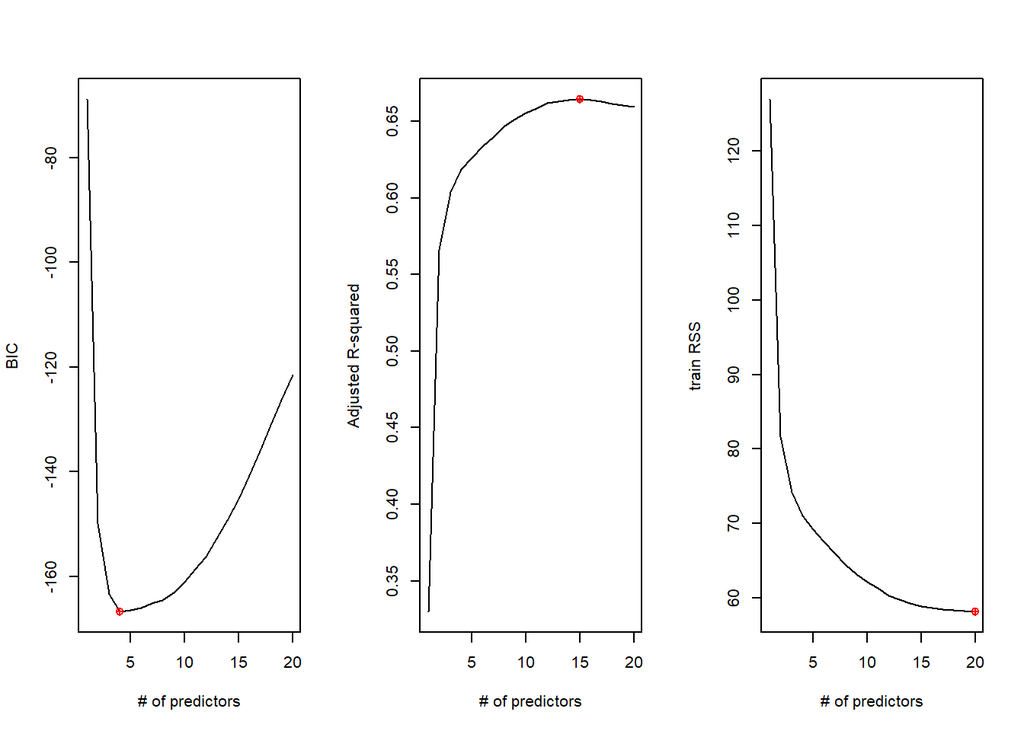

```r
par(mfrow=c(1,3))
bics<-summary(reg.fwd)$bic
plot(1:20,bics,type="l",ylab="BIC",xlab="# of predictors")
index<-which(bics==min(bics))
points(index,bics[index],col="red",pch=10)

adjr2<-summary(reg.fwd)$adjr2
plot(1:20,adjr2,type="l",ylab="Adjusted R-squared",xlab="# of predictors")
index<-which(adjr2==max(adjr2))
points(index,adjr2[index],col="red",pch=10)

rss<-summary(reg.fwd)$rss
plot(1:20,rss,type="l",ylab="train RSS",xlab="# of predictors")
index<-which(rss==min(rss))
points(index,rss[index],col="red",pch=10)
```

If using the BIC metric, it selects four predictors that should be used. To see which predictors are included we can run the following code chunk. Repeat this code to examine what predictors are kept if you selected the model based on Adjusted R-squared and residual sums of squares (train MSE). Which metric do you think you trust the most if I told you the “mystery variables” were randomly generated by me? When looking at Adjusted R-squared does the graph suggest as many predictors are needed as the maximum R square suggests? If the V* metrics were generated by you, I would trust the BIC value as it does not include any of the “mystery” values. As with the Adjusted-RSquared Values, the graph does suggest that we should stop adding more predictors as the value reaches it’s peak.

```r
coef(reg.fwd,4)
```

```
##  (Intercept)       Greens     AvgPutts         Save       Events
##  32.98715837   0.17393243 -19.22206757   0.02501048  -0.03953744
```

```r
coef(reg.fwd,16)
```

```
##  (Intercept)     DriveAcc       Greens     AvgPutts         Save       Events
##  33.78513381  -0.01774246   0.18595215 -19.32937420   0.03068104  -0.04285777
##          V12          V13          V17          V18          V20          V21
##   0.07926933   0.09269538  -0.10341446  -0.10032632  -0.05847031   0.06684297
##          V23          V25          V27          V30          V31
##   0.08029921   0.07114279  -0.03876871  -0.06131502  -0.03419328
```

```r
coef(reg.fwd,20)
```

```
##   (Intercept)      AvgDrive      DriveAcc        Greens      AvgPutts
##  36.084713575  -0.004970967  -0.023350848   0.192950061 -19.314297163
##          Save        Events           V12           V13           V14
##   0.029913559  -0.042030325   0.081123285   0.094612062  -0.027722815
##           V17           V18           V19           V20           V21
##  -0.102892758  -0.102706368  -0.030800932  -0.053525963   0.069320679
##           V23           V25           V27           V29           V30
##   0.081798902   0.074281191  -0.040237948   0.028339486  -0.059941420
##           V31
##  -0.031837376
```

C. The previous codes fit a model using the entire golf data set. The next set of code splits the data set into a training and validation set (50/50) and provides the MSE metric for both sets. What does the validation MSE suggest the appropriate number of predictors should be? Are there any signs of overfitting based on the graphic? What happens if you change the split to 80/20?

Yes, the plot suggests that we should use 3 predictors and the model maybe overfitted to the training set. When you add more and more predictors to the model, the RMSE for the training data decreases and the RMSE for the validation set increases. One could come to the conclusion that the model captured the complexities of data that doesn’t effectively contribute to the predicting Avg. Winnings. When you change the proprtion to an 80/20 split, the optimal predictors count rises to 11.

```r
library(caret)
```

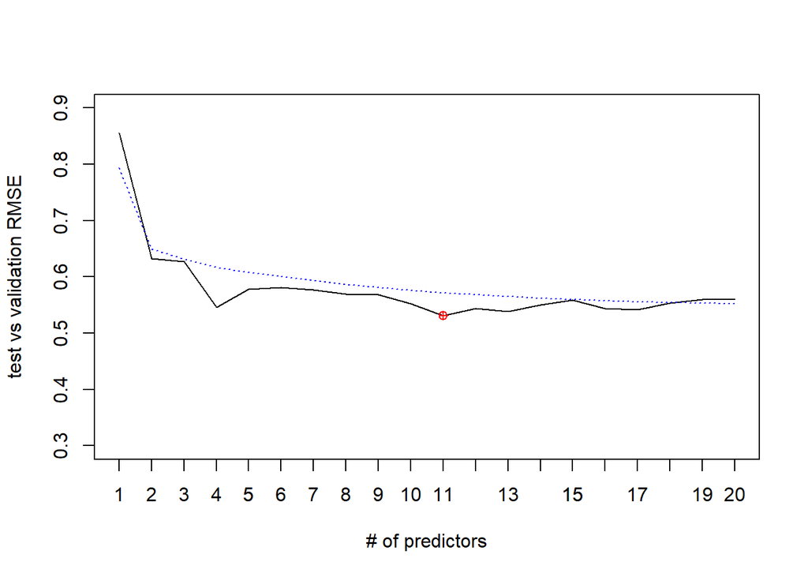

```r
set.seed(1234)
trainIndex<-createDataPartition(golf2$AvgWinnings,p=.8,list=F)  #p: proportion of data in train

training<-golf2[trainIndex,]
validate<-golf2[-trainIndex,]

fwd.train=regsubsets(log(AvgWinnings)~.,data=training,method="forward",nvmax=20)

#Creating a prediction function
predict.regsubsets =function (object , newdata ,id ,...){
  form=as.formula (object$call [[2]])
  mat=model.matrix(form ,newdata )
  coefi=coef(object ,id=id)
  xvars=names(coefi)
  mat[,xvars]%*%coefi
}

valMSE<-c()
#note my index, i, is to 20 since that is how many predictors I went up to during fwd selection
for (i in 1:20){
  predictions<-predict.regsubsets(object=fwd.train,newdata=validate,id=i)
  valMSE[i]<-mean((log(validate$AvgWinnings)-predictions)^2)
}
par(mfrow=c(1,1))
plot(1:20,sqrt(valMSE),type="l",xlab="# of predictors",ylab="test vs validation RMSE",ylim=c(0.3,.9))
index<-which(valMSE==min(valMSE))
points(index,sqrt(valMSE[index]),col="red",pch=10)

trainMSE<-summary(fwd.train)$rss/nrow(training)
lines(1:20,sqrt(trainMSE),lty=3,col="blue")

axis(1, at=seq(1, 20, by=1))
```

## GLMNET and Cross Validation

The following code chunk performs the glmnet procedure using `caret` and compares the MSE values via repeated 10-fold cross validation for various mixing and penalty terms.

```r
library(caret)
set.seed(1234)

fitControl<-trainControl(method="repeatedcv",number=10,repeats=10)
glmnet.fit<-train(log(AvgWinnings)~.,
               data=golf2,
               method="glmnet",
               trControl=fitControl
               )
glmnet.fit
```

```
## glmnet
##
## 196 samples
##  27 predictor
##
## No pre-processing
## Resampling: Cross-Validated (10 fold, repeated 10 times)
## Summary of sample sizes: 176, 178, 176, 177, 177, 176, ...
## Resampling results across tuning parameters:
##
##   alpha  lambda       RMSE       Rsquared   MAE
##   0.10   0.001137415  0.6305772  0.5964487  0.5189343
##   0.10   0.011374155  0.6287136  0.5973913  0.5172888
##   0.10   0.113741547  0.6193615  0.6066092  0.5059088
##   0.55   0.001137415  0.6304031  0.5967984  0.5188379
##   0.55   0.011374155  0.6228292  0.6026313  0.5125484
##   0.55   0.113741547  0.6302600  0.6041683  0.5169850
##   1.00   0.001137415  0.6299355  0.5972033  0.5184713
##   1.00   0.011374155  0.6175146  0.6079286  0.5078276
##   1.00   0.113741547  0.6438276  0.6008456  0.5263401
##
## RMSE was used to select the optimal model using the smallest value.
## The final values used for the model were alpha = 1 and lambda = 0.01137415.
```

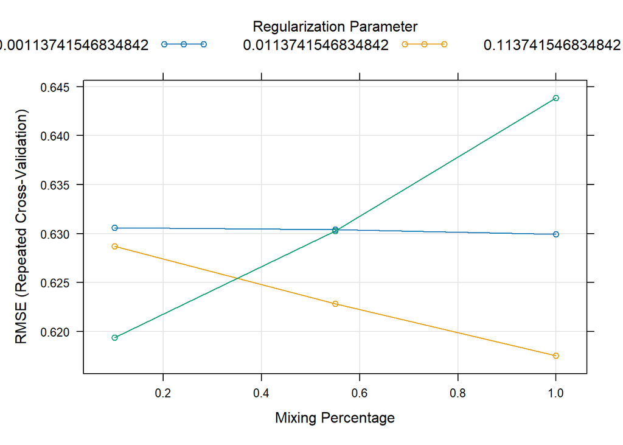

```r
plot(glmnet.fit)
```

```r
opt.pen<-glmnet.fit$finalModel$lambdaOpt #penalty term
coef(glmnet.fit$finalModel,opt.pen)
```

```
## 28 x 1 sparse Matrix of class "dgCMatrix"
##              s=0.01137415
## (Intercept)  3.457540e+01
## Age         -8.733798e-04
## AvgDrive     .
## DriveAcc    -1.396854e-02
## Greens       1.803266e-01
## AvgPutts    -1.905866e+01
## Save         2.768164e-02
## Events      -4.023300e-02
## V12          6.671971e-02
## V13          7.652751e-02
## V14         -1.715237e-02
## V15          .
## V16          .
## V17         -8.801762e-02
## V18         -8.599175e-02
## V19         -1.800267e-02
## V20         -4.190729e-02
## V21          5.584152e-02
## V22          .
## V23          6.611264e-02
## V24          .
## V25          6.033225e-02
## V26          .
## V27         -2.672171e-02
## V28         -3.932099e-03
## V29          6.963435e-03
## V30         -4.890659e-02
## V31         -2.297226e-02
```

```r
glmnet.fit$results
```

```
##   alpha      lambda      RMSE  Rsquared       MAE     RMSESD RsquaredSD
## 1  0.10 0.001137415 0.6305772 0.5964487 0.5189343 0.08421099  0.1339849
## 2  0.10 0.011374155 0.6287136 0.5973913 0.5172888 0.08385824  0.1340101
## 3  0.10 0.113741547 0.6193615 0.6066092 0.5059088 0.08235596  0.1334051
## 4  0.55 0.001137415 0.6304031 0.5967984 0.5188379 0.08408957  0.1338449
## 5  0.55 0.011374155 0.6228292 0.6026313 0.5125484 0.08225847  0.1326715
## 6  0.55 0.113741547 0.6302600 0.6041683 0.5169850 0.08271318  0.1335984
## 7  1.00 0.001137415 0.6299355 0.5972033 0.5184713 0.08397424  0.1337943
## 8  1.00 0.011374155 0.6175146 0.6079286 0.5078276 0.08115944  0.1312567
## 9  1.00 0.113741547 0.6438276 0.6008456 0.5263401 0.08613309  0.1349116
##        MAESD
## 1 0.07620558
## 2 0.07602393
## 3 0.07439313
## 4 0.07607370
## 5 0.07481195
## 6 0.06868900
## 7 0.07599265
## 8 0.07422223
## 9 0.07025129
```

A. Examine the output graphics and determine if a glmnet, LASSO, or Ridge regression model was preferred. Compare the feature selection results relative to the forward selection results in the previous selection. In particular, what predictors are included in the model or not?

From the glmnet.fit output, the function determined to use LASSO. There are alot of predictors added in the model. Age, DriveAcc, Greens, AvgPutts, Save, Events V12/13/14/17/18/19/20/21/23/25/27/28/29/30/31.

2. The previous results in part A may have some folks worried. There is another package that can run glmnet specifically that has some additional options to discuss. Run the following code, and compare the penalty term and the resulting predictors selected from this version of GLMNET compared to the previous one. What do you think about this result compared to the result in part A?

I like this one ALOT more. It uses less predictors AND, its less complicated of a model.

```r
x=model.matrix(AvgWinnings~.,golf2)[,-1]
y=log(golf2$AvgWinnings)

library(glmnet)
```

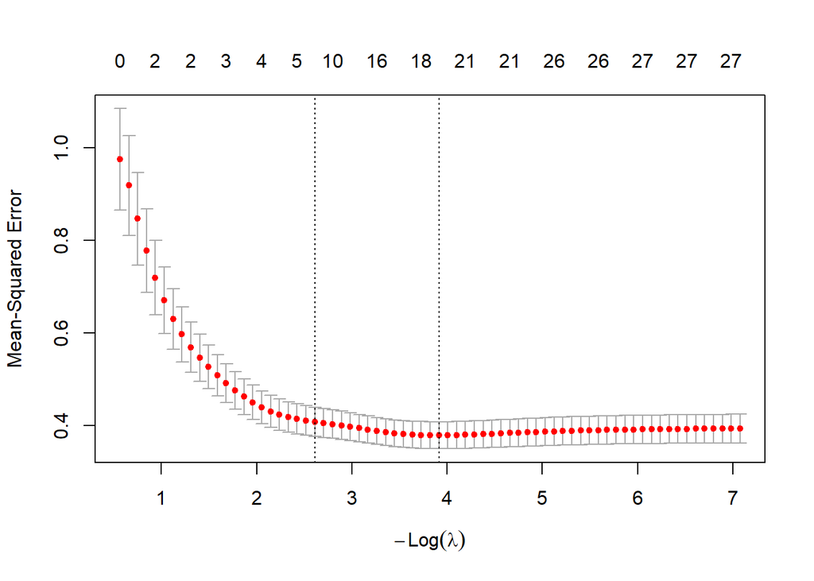

```r
set.seed(1234)

#grid=10^seq(10,-2, length =100)
#lasso.mod=glmnet(x,y,alpha=1, lambda =grid)

cv.out=cv.glmnet(x,y,alpha=1)
plot(cv.out)
```

```r
bestlambda<-cv.out$lambda.1se
coef(cv.out,s=bestlambda)
```

```
## 28 x 1 sparse Matrix of class "dgCMatrix"
##             s=0.07345143
## (Intercept)  34.21411790
## Age           .
## AvgDrive      .
## DriveAcc      .
## Greens        0.14861219
## AvgPutts    -17.54870783
## Save          0.01418931
## Events       -0.02663602
## V12           .
## V13           .
## V14           .
## V15           .
## V16           .
## V17          -0.01938770
## V18          -0.01445805
## V19           .
## V20           .
## V21           .
## V22           .
## V23           .
## V24           .
## V25           .
## V26           .
## V27           .
## V28           .
## V29           .
## V30           .
## V31           .
```